# NYC Flight Data

STAT 230

3/30/2017

## Packages

```r
library(nycflights13)
library(dplyr)
```

```r
library(tidyr)
library(ggplot2)
```

## The Data

```r
dim(flights)
```

```
## [1] 336776     19
```

```r
flights
```

```
## # A tibble: 336,776 × 19
##     year month   day dep_time sched_dep_time dep_delay arr_time
##    <int> <int> <int>    <int>          <int>     <dbl>    <int>
## 1   2013     1     1      517            515         2      830
## 2   2013     1     1      533            529         4      850
## 3   2013     1     1      542            540         2      923
## 4   2013     1     1      544            545        -1     1004
## 5   2013     1     1      554            600        -6      812
## 6   2013     1     1      554            558        -4      740
## 7   2013     1     1      555            600        -5      913
## 8   2013     1     1      557            600        -3      709
## 9   2013     1     1      557            600        -3      838
## 10  2013     1     1      558            600        -2      753
## # ... with 336,766 more rows, and 12 more variables: sched_arr_time <int>,
## #   arr_delay <dbl>, carrier <chr>, flight <int>, tailnum <chr>,
## #   origin <chr>, dest <chr>, air_time <dbl>, distance <dbl>, hour <dbl>,
## #   minute <dbl>, time_hour <dttm>
```

```r
summary(flights)
```

```
##       year          month             day           dep_time
##  Min.   :2013   Min.   : 1.000   Min.   : 1.00   Min.   :   1
##  1st Qu.:2013   1st Qu.: 4.000   1st Qu.: 8.00   1st Qu.: 907
##  Median :2013   Median : 7.000   Median :16.00   Median :1401
##  Mean   :2013   Mean   : 6.549   Mean   :15.71   Mean   :1349
##  3rd Qu.:2013   3rd Qu.:10.000   3rd Qu.:23.00   3rd Qu.:1744
##  Max.   :2013   Max.   :12.000   Max.   :31.00   Max.   :2400
##                                                  NA's   :8255
##  sched_dep_time   dep_delay          arr_time    sched_arr_time
##  Min.   : 106   Min.   : -43.00   Min.   :   1   Min.   :   1
##  1st Qu.: 906   1st Qu.:  -5.00   1st Qu.:1104   1st Qu.:1124
##  Median :1359   Median :  -2.00   Median :1535   Median :1556
##  Mean   :1344   Mean   :  12.64   Mean   :1502   Mean   :1536
##  3rd Qu.:1729   3rd Qu.:  11.00   3rd Qu.:1940   3rd Qu.:1945
##  Max.   :2359   Max.   :1301.00   Max.   :2400   Max.   :2359
##                 NA's   :8255      NA's   :8713
##    arr_delay          carrier              flight       tailnum
##  Min.   : -86.000   Length:336776      Min.   :   1   Length:336776
##  1st Qu.: -17.000   Class :character   1st Qu.: 553   Class :character
##  Median :  -5.000   Mode  :character   Median :1496   Mode  :character
##  Mean   :   6.895                      Mean   :1972
##  3rd Qu.:  14.000                      3rd Qu.:3465
##  Max.   :1272.000                      Max.   :8500
##  NA's   :9430
##     origin              dest              air_time        distance
##  Length:336776      Length:336776      Min.   : 20.0   Min.   :  17
##  Class :character   Class :character   1st Qu.: 82.0   1st Qu.: 502
##  Mode  :character   Mode  :character   Median :129.0   Median : 872
##                                        Mean   :150.7   Mean   :1040
##                                        3rd Qu.:192.0   3rd Qu.:1389
##                                        Max.   :695.0   Max.   :4983
##                                        NA's   :9430
##       hour           minute        time_hour
##  Min.   : 1.00   Min.   : 0.00   Min.   :2013-01-01 05:00:00
##  1st Qu.: 9.00   1st Qu.: 8.00   1st Qu.:2013-04-04 13:00:00
##  Median :13.00   Median :29.00   Median :2013-07-03 10:00:00
##  Mean   :13.18   Mean   :26.23   Mean   :2013-07-03 05:02:36
##  3rd Qu.:17.00   3rd Qu.:44.00   3rd Qu.:2013-10-01 07:00:00
##  Max.   :23.00   Max.   :59.00   Max.   :2013-12-31 23:00:00
##
```

### Filtering by Row

`filter()` allows us to filter a dataset by row.

Suppose we want to just look at flights that departed on New Year’s Day.

```r
newyears <- filter(flights, month == 1, day == 1)

newyears <- filter(flights, month == 1 & day == 1)
head(newyears)
```

```
## # A tibble: 6 × 19
##    year month   day dep_time sched_dep_time dep_delay arr_time
##   <int> <int> <int>    <int>          <int>     <dbl>    <int>
## 1  2013     1     1      517            515         2      830
## 2  2013     1     1      533            529         4      850
## 3  2013     1     1      542            540         2      923
## 4  2013     1     1      544            545        -1     1004
## 5  2013     1     1      554            600        -6      812
## 6  2013     1     1      554            558        -4      740
## # ... with 12 more variables: sched_arr_time <int>, arr_delay <dbl>,
## #   carrier <chr>, flight <int>, tailnum <chr>, origin <chr>, dest <chr>,
## #   air_time <dbl>, distance <dbl>, hour <dbl>, minute <dbl>,
## #   time_hour <dttm>
```

```r
tail(newyears)
```

```
## # A tibble: 6 × 19
##    year month   day dep_time sched_dep_time dep_delay arr_time
##   <int> <int> <int>    <int>          <int>     <dbl>    <int>
## 1  2013     1     1     2353           2359        -6      418
## 2  2013     1     1     2356           2359        -3      425
## 3  2013     1     1       NA           1630        NA       NA
## 4  2013     1     1       NA           1935        NA       NA
## 5  2013     1     1       NA           1500        NA       NA
## 6  2013     1     1       NA            600        NA       NA
## # ... with 12 more variables: sched_arr_time <int>, arr_delay <dbl>,
## #   carrier <chr>, flight <int>, tailnum <chr>, origin <chr>, dest <chr>,
## #   air_time <dbl>, distance <dbl>, hour <dbl>, minute <dbl>,
## #   time_hour <dttm>
```

```r
newyears <- flights %>% filter(month == 1, day == 1)
```

### Selecting columns

`select()` allows us to extract one or more columns from a data frame.

```r
newyears %>% select(dep_delay)
```

```
## # A tibble: 842 × 1
##    dep_delay
##        <dbl>
## 1          2
## 2          4
## 3          2
## 4         -1
## 5         -6
## 6         -4
## 7         -5
## 8         -3
## 9         -3
## 10        -2
## # ... with 832 more rows
```

```r
colnames(newyears)
```

```
##  [1] "year"           "month"          "day"            "dep_time"
##  [5] "sched_dep_time" "dep_delay"      "arr_time"       "sched_arr_time"
##  [9] "arr_delay"      "carrier"        "flight"         "tailnum"
## [13] "origin"         "dest"           "air_time"       "distance"
## [17] "hour"           "minute"         "time_hour"
```

```r
newyears %>% select(starts_with("arr"))
```

```
## # A tibble: 842 × 2
##    arr_time arr_delay
##       <int>     <dbl>
## 1       830        11
## 2       850        20
## 3       923        33
## 4      1004       -18
## 5       812       -25
## 6       740        12
## 7       913        19
## 8       709       -14
## 9       838        -8
## 10      753         8
## # ... with 832 more rows
```

```r
newyears %>% select(contains("arr_"))
```

```
## # A tibble: 842 × 3
##    arr_time sched_arr_time arr_delay
##       <int>          <int>     <dbl>
## 1       830            819        11
## 2       850            830        20
## 3       923            850        33
## 4      1004           1022       -18
## 5       812            837       -25
## 6       740            728        12
## 7       913            854        19
## 8       709            723       -14
## 9       838            846        -8
## 10      753            745         8
## # ... with 832 more rows
```

```r
newyears %>% select(7:9)
```

```
## # A tibble: 842 × 3
##    arr_time sched_arr_time arr_delay
##       <int>          <int>     <dbl>
## 1       830            819        11
## 2       850            830        20
## 3       923            850        33
## 4      1004           1022       -18
## 5       812            837       -25
## 6       740            728        12
## 7       913            854        19
## 8       709            723       -14
## 9       838            846        -8
## 10      753            745         8
## # ... with 832 more rows
```

```r
newyears %>% select(arr_time:arr_delay)
```

```
## # A tibble: 842 × 3
##    arr_time sched_arr_time arr_delay
##       <int>          <int>     <dbl>
## 1       830            819        11
## 2       850            830        20
## 3       923            850        33
## 4      1004           1022       -18
## 5       812            837       -25
## 6       740            728        12
## 7       913            854        19
## 8       709            723       -14
## 9       838            846        -8
## 10      753            745         8
## # ... with 832 more rows
```

```r
newyears %>% select(-(arr_time:arr_delay))
```

```
## # A tibble: 842 × 16
##     year month   day dep_time sched_dep_time dep_delay carrier flight
##    <int> <int> <int>    <int>          <int>     <dbl>   <chr>  <int>
## 1   2013     1     1      517            515         2      UA   1545
## 2   2013     1     1      533            529         4      UA   1714
## 3   2013     1     1      542            540         2      AA   1141
## 4   2013     1     1      544            545        -1      B6    725
## 5   2013     1     1      554            600        -6      DL    461
## 6   2013     1     1      554            558        -4      UA   1696
## 7   2013     1     1      555            600        -5      B6    507
## 8   2013     1     1      557            600        -3      EV   5708
## 9   2013     1     1      557            600        -3      B6     79
## 10  2013     1     1      558            600        -2      AA    301
## # ... with 832 more rows, and 8 more variables: tailnum <chr>,
## #   origin <chr>, dest <chr>, air_time <dbl>, distance <dbl>, hour <dbl>,
## #   minute <dbl>, time_hour <dttm>
```

```r
newyears %>% select(-starts_with("arr"))
```

```
## # A tibble: 842 × 17
##     year month   day dep_time sched_dep_time dep_delay sched_arr_time
##    <int> <int> <int>    <int>          <int>     <dbl>          <int>
## 1   2013     1     1      517            515         2            819
## 2   2013     1     1      533            529         4            830
## 3   2013     1     1      542            540         2            850
## 4   2013     1     1      544            545        -1           1022
## 5   2013     1     1      554            600        -6            837
## 6   2013     1     1      554            558        -4            728
## 7   2013     1     1      555            600        -5            854
## 8   2013     1     1      557            600        -3            723
## 9   2013     1     1      557            600        -3            846
## 10  2013     1     1      558            600        -2            745
## # ... with 832 more rows, and 10 more variables: carrier <chr>,
## #   flight <int>, tailnum <chr>, origin <chr>, dest <chr>, air_time <dbl>,
## #   distance <dbl>, hour <dbl>, minute <dbl>, time_hour <dttm>
```

Getting distinct values of `carrier`:

```r
newyears %>% select(carrier) %>% distinct()
```

```
## # A tibble: 14 × 1
##    carrier
##      <chr>
## 1       UA
## 2       AA
## 3       B6
## 4       DL
## 5       EV
## 6       MQ
## 7       US
## 8       WN
## 9       VX
## 10      FL
## 11      AS
## 12      9E
## 13      F9
## 14      HA
```

### Arranging the Data

```r
newyears %>% arrange(sched_dep_time, dep_delay)
```

```
## # A tibble: 842 × 19
##     year month   day dep_time sched_dep_time dep_delay arr_time
##    <int> <int> <int>    <int>          <int>     <dbl>    <int>
## 1   2013     1     1      517            515         2      830
## 2   2013     1     1      533            529         4      850
## 3   2013     1     1      542            540         2      923
## 4   2013     1     1      544            545        -1     1004
## 5   2013     1     1      554            558        -4      740
## 6   2013     1     1      559            559         0      702
## 7   2013     1     1      554            600        -6      812
## 8   2013     1     1      555            600        -5      913
## 9   2013     1     1      557            600        -3      709
## 10  2013     1     1      557            600        -3      838
## # ... with 832 more rows, and 12 more variables: sched_arr_time <int>,
## #   arr_delay <dbl>, carrier <chr>, flight <int>, tailnum <chr>,
## #   origin <chr>, dest <chr>, air_time <dbl>, distance <dbl>, hour <dbl>,
## #   minute <dbl>, time_hour <dttm>
```

```r
newyears %>% arrange(sched_dep_time, desc(dep_delay))
```

```
## # A tibble: 842 × 19
##     year month   day dep_time sched_dep_time dep_delay arr_time
##    <int> <int> <int>    <int>          <int>     <dbl>    <int>
## 1   2013     1     1      517            515         2      830
## 2   2013     1     1      533            529         4      850
## 3   2013     1     1      542            540         2      923
## 4   2013     1     1      544            545        -1     1004
## 5   2013     1     1      554            558        -4      740
## 6   2013     1     1      559            559         0      702
## 7   2013     1     1      611            600        11      945
## 8   2013     1     1      608            600         8      807
## 9   2013     1     1      601            600         1      844
## 10  2013     1     1      600            600         0      851
## # ... with 832 more rows, and 12 more variables: sched_arr_time <int>,
## #   arr_delay <dbl>, carrier <chr>, flight <int>, tailnum <chr>,
## #   origin <chr>, dest <chr>, air_time <dbl>, distance <dbl>, hour <dbl>,
## #   minute <dbl>, time_hour <dttm>
```

### Renaming Columns

```r
names(newyears)
```

```
##  [1] "year"           "month"          "day"            "dep_time"
##  [5] "sched_dep_time" "dep_delay"      "arr_time"       "sched_arr_time"
##  [9] "arr_delay"      "carrier"        "flight"         "tailnum"
## [13] "origin"         "dest"           "air_time"       "distance"
## [17] "hour"           "minute"         "time_hour"
```

```r
newyears %>% rename(hr = hour, min = minute)
```

```
## # A tibble: 842 × 19
##     year month   day dep_time sched_dep_time dep_delay arr_time
##    <int> <int> <int>    <int>          <int>     <dbl>    <int>
## 1   2013     1     1      517            515         2      830
## 2   2013     1     1      533            529         4      850
## 3   2013     1     1      542            540         2      923
## 4   2013     1     1      544            545        -1     1004
## 5   2013     1     1      554            600        -6      812
## 6   2013     1     1      554            558        -4      740
## 7   2013     1     1      555            600        -5      913
## 8   2013     1     1      557            600        -3      709
## 9   2013     1     1      557            600        -3      838
## 10  2013     1     1      558            600        -2      753
## # ... with 832 more rows, and 12 more variables: sched_arr_time <int>,
## #   arr_delay <dbl>, carrier <chr>, flight <int>, tailnum <chr>,
## #   origin <chr>, dest <chr>, air_time <dbl>, distance <dbl>, hr <dbl>,
## #   min <dbl>, time_hour <dttm>
```

### Adding new columns

```r
newyears <- newyears %>% mutate(gain = arr_delay - dep_delay)

# the old way of doing this:

# newyears$gain <- newyears$arr_delay - newyears$dep_delay
```

### Summarizing Data

`summarize()` can be used to compute summary statistics based on one or more columns in the data frame.

```r
flights %>% summarize(delay = mean(dep_delay, na.rm=TRUE),
                      numdests = n_distinct(dest))
```

```
## # A tibble: 1 × 2
##      delay numdests
##      <dbl>    <int>
## 1 12.63907      105
```

By hour… what are these summary statistics?

```r
flights %>% group_by(hour) %>%
  summarize(delay = mean(dep_delay, na.rm=TRUE),
                      numdests = n_distinct(dest))
```

```
## # A tibble: 20 × 3
##     hour      delay numdests
##    <dbl>      <dbl>    <int>
## 1      1        NaN        1
## 2      5  0.6877572       23
## 3      6  1.6427956       51
## 4      7  1.9140778       69
## 5      8  4.1279478       78
## 6      9  4.5837378       71
## 7     10  6.4982946       66
## 8     11  7.1916503       66
## 9     12  8.6148485       65
## 10    13 11.4376504       71
## 11    14 13.8188742       67
## 12    15 16.8945646       69
## 13    16 18.7570165       70
## 14    17 21.1006059       73
## 15    18 21.1100818       74
## 16    19 24.7847911       74
## 17    20 24.3041048       72
## 18    21 24.1957431       55
## 19    22 18.7910972       21
## 20    23 14.0171756        6
```

Be careful when inserting line breaks. It’s best to break after the piping operator and not before.

## Some Practice

Q: How many flights go out of NYC each day?

```r
daily <- flights %>% group_by(month, day) %>%
  summarize(numflights = n())

library(lubridate)
flights <- flights %>% mutate(date = ymd(paste(year, month, day)))
head(flights$date)
```

```
## [1] "2013-01-01" "2013-01-01" "2013-01-01" "2013-01-01" "2013-01-01"
## [6] "2013-01-01"
```

```r
tail(flights$date)
```

```
## [1] "2013-09-30" "2013-09-30" "2013-09-30" "2013-09-30" "2013-09-30"
## [6] "2013-09-30"
```

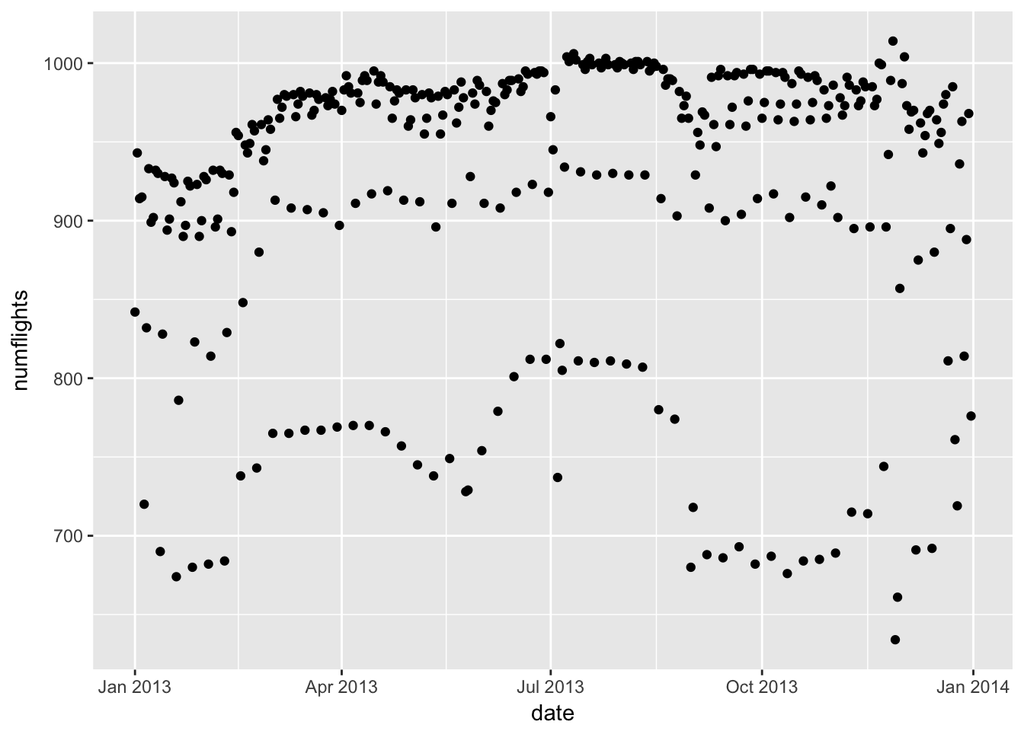

```r
daily <- flights %>% group_by(date) %>%
  summarize(numflights = n())
ggplot(daily, aes(x=date, y= numflights)) + geom_point()
```

How does this break down by day of the week?

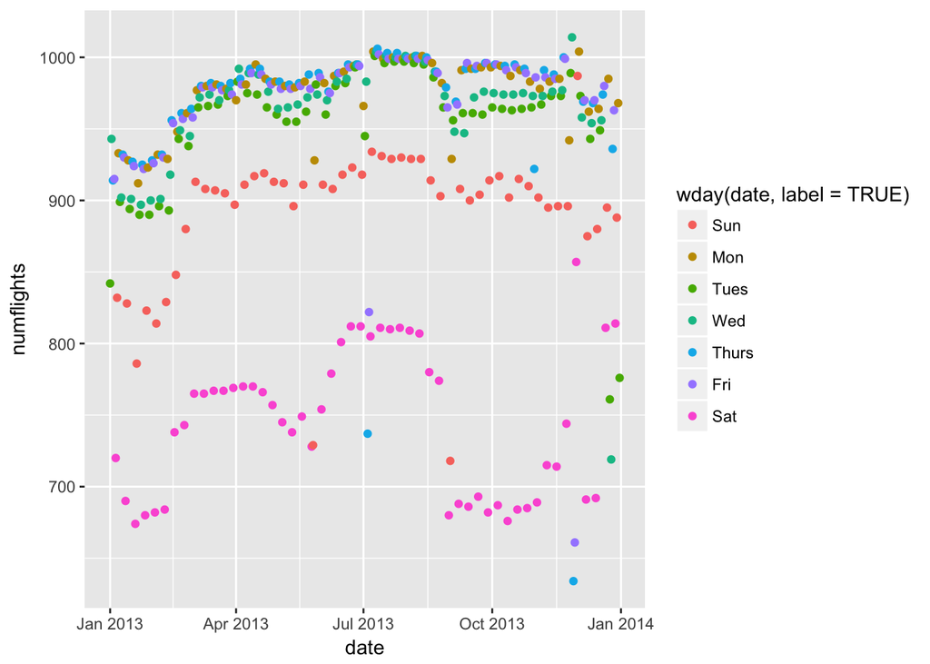

```r
ggplot(daily, aes(x=date, y= numflights,
                  color=wday(date, label=TRUE))) +
  geom_point()
```

Q: Suppose I am flying out of NYC on New Year’s Day. Which airline carriers had the longest average arrival delay?

```r
newyears %>% group_by(carrier) %>%
  summarize(meandelay = mean(arr_delay, na.rm=TRUE))
```

```
## # A tibble: 14 × 2
##    carrier  meandelay
##      <chr>      <dbl>
## 1       9E  12.481481
## 2       AA  11.445652
## 3       AS -14.500000
## 4       B6   8.641975
## 5       DL  -7.580357
## 6       EV  41.366071
## 7       F9  13.000000
## 8       FL   5.300000
## 9       HA -14.000000
## 10      MQ  33.315789
## 11      UA   6.268293
## 12      US   1.156250
## 13      VX -12.166667
## 14      WN  16.740741
```

(This is not a well-posed question… why?)

Let’s just consider flights to FLL (Fort Lauderdale):

```r
newyears %>% filter(dest == "FLL") %>%
  group_by(carrier) %>%
  summarize(meandelay = mean(arr_delay, na.rm=TRUE))
```

```
## # A tibble: 4 × 2
##   carrier  meandelay
##     <chr>      <dbl>
## 1      AA -13.000000
## 2      B6   7.380952
## 3      DL -15.666667
## 4      UA   1.666667
```

Or a plot:

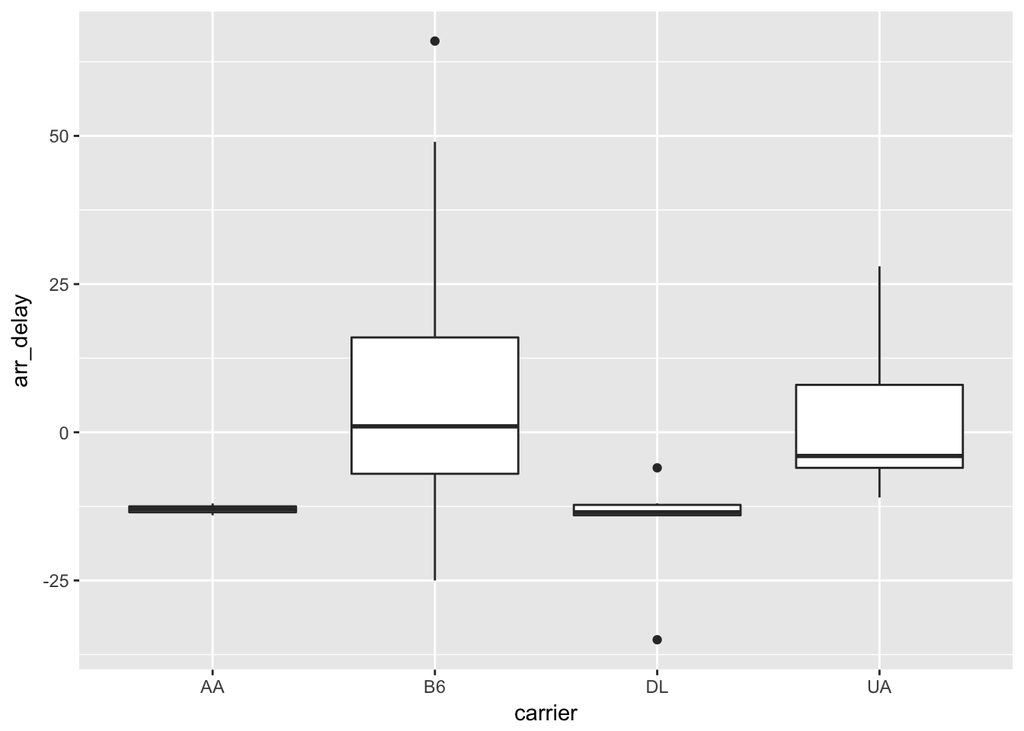

```r
newyears %>% filter(dest == "FLL") %>%
  ggplot(aes(x= carrier, y = arr_delay)) +
  geom_boxplot()
```

Q: What do the NA’s mean?

```r
newyears %>% filter(is.na(arr_delay)) %>% select(-(1:3))
```

```
## # A tibble: 11 × 17
##    dep_time sched_dep_time dep_delay arr_time sched_arr_time arr_delay
##       <int>          <int>     <dbl>    <int>          <int>     <dbl>
## 1      1525           1530        -5     1934           1805        NA
## 2      1528           1459        29     2002           1647        NA
## 3      1740           1745        -5     2158           2020        NA
## 4      1807           1738        29     2251           2103        NA
## 5      1939           1840        59       29           2151        NA
## 6      1952           1930        22     2358           2207        NA
## 7      2016           1930        46       NA           2220        NA
## 8        NA           1630        NA       NA           1815        NA
## 9        NA           1935        NA       NA           2240        NA
## 10       NA           1500        NA       NA           1825        NA
## 11       NA            600        NA       NA            901        NA
## # ... with 11 more variables: carrier <chr>, flight <int>, tailnum <chr>,
## #   origin <chr>, dest <chr>, air_time <dbl>, distance <dbl>, hour <dbl>,
## #   minute <dbl>, time_hour <dttm>, gain <dbl>
```

It appears that some NAs are legitimate cancellations. Others might be fixable (with some work), but we’ll choose to remove the NAs at this point.

```r
flights <- flights %>% filter(!is.na(arr_delay) & !is.na(dep_delay))
dim(flights)
```

```
## [1] 327346     20
```

Q: Consider the flights between NYC and BOS (Boston) each day. What are the average delays per hour of the day for each carrier?

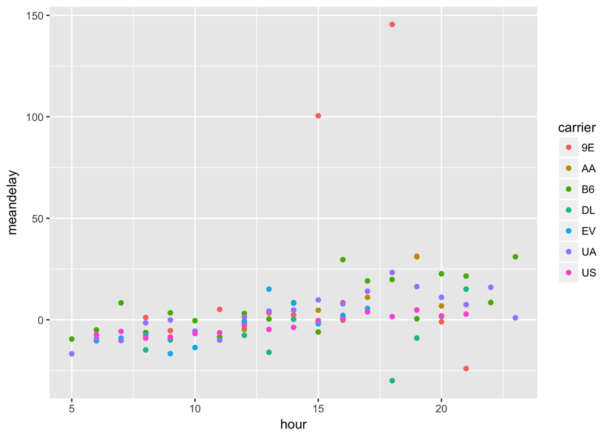

```r
tmp <- flights %>% filter(dest == "BOS") %>% group_by(carrier, hour) %>%
  summarize(meandelay = mean(arr_delay))

ggplot(tmp, aes(x=hour, y=meandelay, color=carrier)) + geom_point()
```

Break this down further by airport of origin:

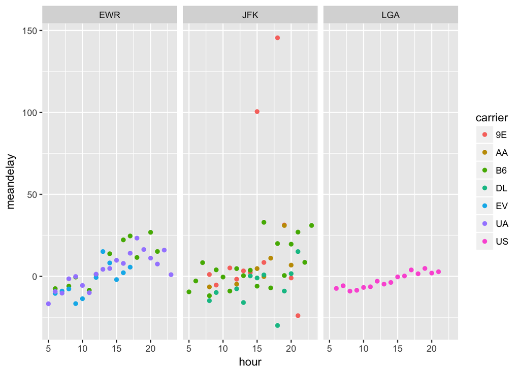

```r
tmp <- flights %>% filter(dest == "BOS") %>%
  group_by(carrier, hour, origin) %>%
  summarize(meandelay = mean(arr_delay))

ggplot(tmp, aes(x=hour, y=meandelay, color=carrier)) + geom_point() + facet_wrap(~origin)
```

Break this down further by day of the week:

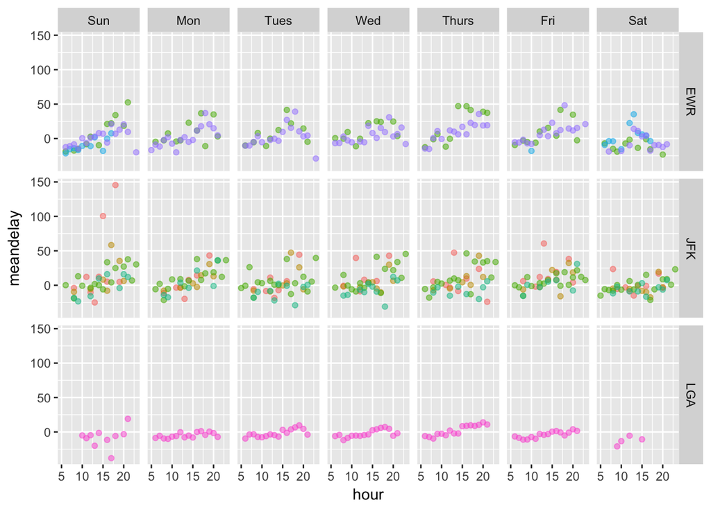

```r
tmp <- flights %>% filter(dest == "BOS") %>%
  mutate(day_of_week = wday(date, label = TRUE)) %>%
  group_by(carrier, hour, origin, day_of_week) %>%
  summarize(meandelay = mean(arr_delay))

ggplot(tmp, aes(x=hour, y=meandelay, color=carrier)) + geom_point(alpha=0.5) + facet_grid(origin ~ day_of_week) +
  theme(legend.position = "none")
```

Q: How many flights are available at each of these combinations of variables?

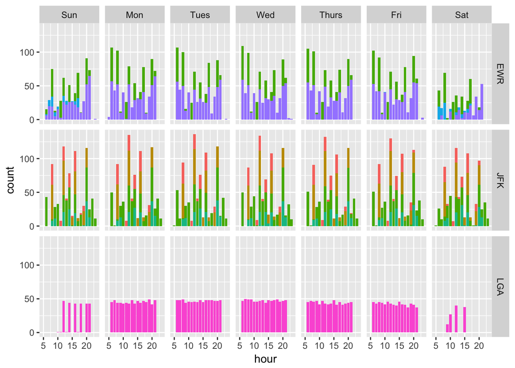

```r
tmp <- flights %>% filter(dest == "BOS") %>%
  mutate(day_of_week = wday(date, label = TRUE)) %>%
  group_by(carrier, hour, origin, day_of_week) %>%
  summarize(nflights = n())

ggplot(tmp, aes(x=hour)) + geom_bar(aes(weight=nflights, fill = carrier)) + facet_grid(origin ~ day_of_week) +
  theme(legend.position = "none")
```